```python
#AML Final project
import pandas as pd
import numpy as np
import os
import glob
import matplotlib.pyplot as plt
import warnings
warnings.filterwarnings('ignore')
```

```python
os.chdir(r"C:\Key files- GNA\Indiana University\Applied Machine Learning\Final project")
btc_raw_data=pd.read_csv('tweets_1_yr_aggregated_data.csv',sep=',')
```

# Exploring the raw data

```python
btc_raw_data.info()
```

```
<class 'pandas.core.frame.DataFrame'>
RangeIndex: 21508513 entries, 0 to 21508512
Data columns (total 11 columns):
 #   Column          Dtype
---  ------          -----
 0   Datetime        object
 1   Tweet Id        object
 2   Text            object
 3   Username        object
 4   replyCount      float64
 5   retweetCount    float64
 6   likeCount       object
 7   quoteCount      float64
 8   lang            object
 9   retweetedTweet  float64
 10  quotedTweet     object
dtypes: float64(4), object(7)
memory usage: 1.8+ GB
```

```python
btc_raw_data.head()
```

|  | Datetime | Tweet Id | Text | Username | replyCount | retweetCount | likeCount | quoteCount | lang | retweetedTweet | quotedTweet |
| --- | --- | --- | --- | --- | --- | --- | --- | --- | --- | --- | --- |
| 0 | 2021-05-01 23:59:57+00:00 | 1.38864E+18 | #Investing 67.1% in this optimal #crypto portf... | CryptoWatchBot | 0.0 | 1.0 | 2 | 0.0 | en | NaN | NaN |
| 1 | 2021-05-01 23:59:54+00:00 | 1.38864E+18 | @HammerToe @Ivan02812917 @EyesUpGames @M14CL @... | _carter | 2.0 | 0.0 | 0 | 0.0 | en | NaN | NaN |
| 2 | 2021-05-01 23:59:42+00:00 | 1.38864E+18 | @TreyLockerbie @1e9petrichor And yet they don'... | MadrilenosLos | 2.0 | 0.0 | 14 | 0.0 | en | NaN | NaN |
| 3 | 2021-05-01 23:59:40+00:00 | 1.38864E+18 | It's a good time to send #Bitcoin transactions... | bitcoin_curious | 0.0 | 0.0 | 0 | 0.0 | en | NaN | NaN |
| 4 | 2021-05-01 23:59:40+00:00 | 1.38864E+18 | Why is everyone always looking for tips on get... | kifffin | 0.0 | 1.0 | 0 | 0.0 | en | NaN | NaN |

```python
btc_raw_data.shape
```

```
(21508513, 11)
```

```python
#Tweets per day
btc_raw_data.shape[0]/351
```

```
61277.81481481482
```

Exploring the volume of English Tweets

~ 70% of tweets are in English

```python
# tweet language by percentages
#btc_raw_data['lang'].value_counts()*100/btc_raw_data.shape[0]
```

Keeping only English Tweets

```python
btc_raw_data_eng=btc_raw_data[btc_raw_data.lang=="en"]
btc_raw_data_eng.shape
```

```
(15743347, 11)
```

```python
#English tweets per day
btc_raw_data_eng.shape[0]/351
```

```
44852.84045584046
```

```python
#btc_raw_data_eng.to_csv("btc_raw_data_eng.csv",index=False)
```

```python
#btc_raw_data_eng=pd.read_csv('btc_raw_data_eng.csv',sep=',')
```

# Extracting important features from the Raw Data

1) Tweet volume

```python
#Getting tweet volume column
btc_raw_data_eng["Datetime"]=pd.to_datetime(btc_raw_data_eng["Datetime"])
btc_raw_data_eng["Date"]=pd.to_datetime(btc_raw_data_eng["Datetime"]).dt.date
#fico_region_avg_fico= fico_with_region.groupby(['region']).agg({'FICO':'mean'}).reset_index()

#Volume of tweets
day_level_btc_raw_data_eng=btc_raw_data_eng.groupby('Date')['Tweet Id'].count().reset_index()
day_level_btc_raw_data_eng.columns=["Date", "tweet_volume"]
```

2) Tweets above 0/1/10/100/1000 likes

```python
#Getting perc_Tweets_above_0/1/10/100/1000_like
btc_raw_data_eng["likeCount"]=pd.to_numeric(btc_raw_data_eng["likeCount"])

btc_raw_data_eng["likes_greater_than_0"]=np.where(btc_raw_data_eng["likeCount"]>0,1,0)
btc_raw_data_eng["likes_greater_than_1"]=np.where(btc_raw_data_eng["likeCount"]>1,1,0)
btc_raw_data_eng["likes_greater_than_10"]=np.where(btc_raw_data_eng["likeCount"]>10,1,0)
btc_raw_data_eng["likes_greater_than_100"]=np.where(btc_raw_data_eng["likeCount"]>100,1,0)
btc_raw_data_eng["likes_greater_than_1000"]=np.where(btc_raw_data_eng["likeCount"]>1000,1,0)

likes_count= btc_raw_data_eng.groupby(['Date']).agg({'likes_greater_than_0':'sum','likes_greater_than_1':'sum','likes_greater_than_10':'sum','likes_greater_than_100':'sum','likes_greater_than_1000':'sum'}).reset_index()
```

3) Retweet count per day

```python
#Perc_Retweet_count
btc_raw_data_eng["retweetCount"]=pd.to_numeric(btc_raw_data_eng["retweetCount"])
btc_raw_data_eng["retweetCount_greater_than_0"]=np.where(btc_raw_data_eng["retweetCount"]>0,1,0)
retweet_count_to_get_perc=btc_raw_data_eng.groupby(['Date']).agg({'retweetCount_greater_than_0':'sum'}).reset_index()
```

4) Day of the week feature

```python
#Getting day of the week
day_level_btc_raw_data_eng['day_of_week']=pd.to_datetime(day_level_btc_raw_data_eng['Date']).dt.day_name()
```

5) Distinct users

```python
#Getting Distinct users
Distinct_users=btc_raw_data_eng.groupby('Date')['Username'].nunique().reset_index()
Distinct_users.columns=["Date", "distinct_users"]
```

6) Time of day

```python
#Getting Time of day
btc_raw_data_eng["hour_of_day"]= btc_raw_data_eng["Datetime"].dt.hour
btc_raw_data_eng["hour_of_day_0_6"]=np.where(btc_raw_data_eng["hour_of_day"]<6,1,0)
btc_raw_data_eng["hour_of_day_6_12"]=np.where((btc_raw_data_eng["hour_of_day"]>5) & (btc_raw_data_eng["hour_of_day"]<12),1,0)
btc_raw_data_eng["hour_of_day_12_18"]=np.where((btc_raw_data_eng["hour_of_day"]>11) & (btc_raw_data_eng["hour_of_day"]<18),1,0)
btc_raw_data_eng["hour_of_day_18_24"]=np.where((btc_raw_data_eng["hour_of_day"]>17) & (btc_raw_data_eng["hour_of_day"]<24),1,0)
hour_of_day= btc_raw_data_eng.groupby(['Date']).agg({'hour_of_day_0_6':'sum','hour_of_day_6_12':'sum','hour_of_day_12_18':'sum','hour_of_day_18_24':'sum'}).reset_index()
```

7) Sentiment Analysis

```python
#sentiment_per_day=pd.read_csv('sentiment_per_day.csv',sep=',')
#sentiment_per_day["Date"]=pd.to_datetime(sentiment_per_day["Date"]).dt.date
#sentiment_per_day.head()
#sentiment_analysis_1L=pd.read_csv('sentiment_analysis_1L.csv',sep=',')
```

```python
sentiment_analysis_1L=pd.read_csv('sentiment_analysis_1L.csv',sep=',')
sentiment_analysis_1L.columns = ['Date', 'negative_1l', 'neutral_1l', 'positive_1l', 'tweets_by_users_with_followers_1l']
sentiment_analysis_1L["Date"]=pd.to_datetime(sentiment_analysis_1L["Date"]).dt.date
#sentiment_analysis_1L["Date"]=pd.to_datetime(sentiment_analysis_1L["Date"],format='%d-%m-%Y').dt.strftime('%Y-%m-%d')
```

```python
sentiment_analysis_verified=pd.read_csv('sentiment_analysis_verified.csv',sep=',')
sentiment_analysis_verified.columns=['Date', 'negative_verified', 'neutral_verified', 'positive_verified', 'tweets_by_users_with_followers_verified']
sentiment_analysis_verified["Date"]=pd.to_datetime(sentiment_analysis_verified["Date"]).dt.date
#sentiment_analysis_verified["Date"]=pd.to_datetime(sentiment_analysis_verified["Date"]).dt.strftime('%Y-%d-%m')
#sentiment_analysis_verified["Date"]=pd.to_datetime(sentiment_analysis_verified["Date"],format='%d-%m-%Y').dt.strftime('%Y-%m-%d')
```

```python
sentiment_analysis_verified["Date"].head()
```

```
0    2021-05-01
1    2021-05-02
2    2021-05-03
3    2021-05-04
4    2021-05-05
Name: Date, dtype: object
```

Merging all the extracted fields to form one table

```python
#Merging -Skipping sentiment analysis file
#flat_file_list=[likes_count,retweet_count_to_get_perc,Distinct_users,hour_of_day,sentiment_per_day]
flat_file_list=[likes_count,retweet_count_to_get_perc,Distinct_users,hour_of_day,sentiment_analysis_1L,sentiment_analysis_verified]
for new_file in flat_file_list:
    day_level_btc_raw_data_eng=pd.merge(day_level_btc_raw_data_eng,
             new_file,
             how="left",
             left_on='Date',
             right_on='Date')
day_level_btc_raw_data_eng['retweet_perc']=day_level_btc_raw_data_eng['retweetCount_greater_than_0']/day_level_btc_raw_data_eng['tweet_volume']
#day_level_btc_raw_data_eng['sentiment_vol']=day_level_btc_raw_data_eng['positive_tweets']+day_level_btc_raw_data_eng['negative_tweets']+day_level_btc_raw_data_eng['neutral_tweets']
#day_level_btc_raw_data_eng['positive_tweets_perc']=day_level_btc_raw_data_eng['positive_tweets']/day_level_btc_raw_data_eng['sentiment_vol']
#day_level_btc_raw_data_eng['negative_tweets_perc']=day_level_btc_raw_data_eng['negative_tweets']/day_level_btc_raw_data_eng['sentiment_vol']
#day_level_btc_raw_data_eng['neutral_tweets_perc']=day_level_btc_raw_data_eng['neutral_tweets']/day_level_btc_raw_data_eng['sentiment_vol']

#day_level_btc_raw_data_eng.drop(['retweetCount_greater_than_0','positive_tweets','negative_tweets','neutral_tweets','sentiment_vol'], axis=1, inplace=True)
day_level_btc_raw_data_eng.drop(['retweetCount_greater_than_0'], axis=1, inplace=True)
day_level_btc_raw_data_eng['Date']=pd.to_datetime(day_level_btc_raw_data_eng['Date'])
```

```python
day_level_btc_raw_data_eng.shape
```

```
(351, 22)
```

```python
day_level_btc_raw_data_eng.head()
```

|  | Date | tweet_volume | day_of_week | likes_greater_than_0 | likes_greater_than_1 | likes_greater_than_10 | likes_greater_than_100 | likes_greater_than_1000 | distinct_users | hour_of_day_0_6 | ... | hour_of_day_18_24 | negative_1l | neutral_1l | positive_1l | tweets_by_users_with_followers_1l | negative_verified | neutral_verified | positive_verified | tweets_by_users_with_followers_verified | retweet_perc |
| --- | --- | --- | --- | --- | --- | --- | --- | --- | --- | --- | --- | --- | --- | --- | --- | --- | --- | --- | --- | --- | --- |
| 0 | 2021-05-01 | 38231 | Saturday | 16588 | 9177 | 2248 | 476 | 74 | 21262 | 7514 | ... | 11902 | 20.138889 | 34.953704 | 44.907407 | 432 | 19.601329 | 33.887043 | 46.511628 | 301 | 0.144935 |
| 1 | 2021-05-02 | 36966 | Sunday | 15005 | 8179 | 1921 | 383 | 55 | 20199 | 7520 | ... | 9831 | 20.797721 | 36.467236 | 42.735043 | 351 | 20.000000 | 29.803922 | 50.196078 | 255 | 0.134583 |
| 2 | 2021-05-03 | 42909 | Monday | 17770 | 9975 | 2450 | 516 | 63 | 22072 | 8499 | ... | 11780 | 13.257576 | 39.204545 | 47.537879 | 528 | 11.815068 | 36.643836 | 51.541096 | 584 | 0.142721 |
| 3 | 2021-05-04 | 44743 | Tuesday | 18822 | 10588 | 2532 | 484 | 63 | 22983 | 8158 | ... | 12488 | 14.179104 | 43.283582 | 42.537313 | 536 | 11.397849 | 37.419355 | 51.182796 | 465 | 0.143576 |
| 4 | 2021-05-05 | 48410 | Wednesday | 19656 | 10934 | 2660 | 536 | 85 | 24988 | 9646 | ... | 12624 | 15.075377 | 40.536013 | 44.388610 | 597 | 14.988290 | 33.021077 | 51.990632 | 427 | 0.139207 |

5 rows × 22 columns

```python
day_level_btc_raw_data_eng.info()
```

```
<class 'pandas.core.frame.DataFrame'>
Int64Index: 351 entries, 0 to 350
Data columns (total 22 columns):
 #   Column                                   Non-Null Count  Dtype
---  ------                                   --------------  -----
 0   Date                                     351 non-null    datetime64[ns]
 1   tweet_volume                             351 non-null    int64
 2   day_of_week                              351 non-null    object
 3   likes_greater_than_0                     351 non-null    int32
 4   likes_greater_than_1                     351 non-null    int32
 5   likes_greater_than_10                    351 non-null    int32
 6   likes_greater_than_100                   351 non-null    int32
 7   likes_greater_than_1000                  351 non-null    int32
 8   distinct_users                           351 non-null    int64
 9   hour_of_day_0_6                          351 non-null    int32
 10  hour_of_day_6_12                         351 non-null    int32
 11  hour_of_day_12_18                        351 non-null    int32
 12  hour_of_day_18_24                        351 non-null    int32
 13  negative_1l                              351 non-null    float64
 14  neutral_1l                               351 non-null    float64
 15  positive_1l                              351 non-null    float64
 16  tweets_by_users_with_followers_1l        351 non-null    int64
 17  negative_verified                        351 non-null    float64
 18  neutral_verified                         351 non-null    float64
 19  positive_verified                        351 non-null    float64
 20  tweets_by_users_with_followers_verified  351 non-null    int64
 21  retweet_perc                             351 non-null    float64
dtypes: datetime64[ns](1), float64(7), int32(9), int64(4), object(1)
memory usage: 50.7+ KB
```

```python
#day_level_btc_raw_data_eng.to_csv("day_level_raw_data.csv",index=0)
```

Getting the Actual Bitcoin Price data from -

https://finance.yahoo.com/quote/BTC-USD/history/

```python
btc_actual_data=pd.read_csv('BTC-USD_1_year.csv',sep=',')
```

```python
btc_actual_data.info()
```

```
<class 'pandas.core.frame.DataFrame'>
RangeIndex: 392 entries, 0 to 391
Data columns (total 7 columns):
 #   Column     Non-Null Count  Dtype
---  ------     --------------  -----
 0   Date       392 non-null    object
 1   Open       392 non-null    float64
 2   High       392 non-null    float64
 3   Low        392 non-null    float64
 4   Close      392 non-null    float64
 5   Adj Close  392 non-null    float64
 6   Volume     392 non-null    int64
dtypes: float64(5), int64(1), object(1)
memory usage: 21.6+ KB
```

```python
#Keeping only Date, Close and Volume fields
btc_actual_data=btc_actual_data.loc[:,['Date','Close','Volume']]
btc_actual_data.columns=['Date','Bitcoin_Price','Volume']
```

```python
btc_actual_data['Date']=pd.to_datetime(btc_actual_data['Date'])
```

```python
btc_actual_data.shape
```

```
(392, 3)
```

```python
btc_actual_data.describe()
```

|  | Bitcoin_Price | Volume |
| --- | --- | --- |
| count | 392.000000 | 3.920000e+02 |
| mean | 46120.190679 | 3.642656e+10 |
| std | 8886.790415 | 1.534451e+10 |
| min | 29807.347656 | 1.373656e+10 |
| 25% | 39274.204102 | 2.648299e+10 |
| 50% | 44528.314453 | 3.310138e+10 |
| 75% | 51755.625976 | 4.069907e+10 |
| max | 67566.828125 | 1.263581e+11 |

```python
btc_actual_data.head()
```

|  | Date | Bitcoin_Price | Volume |
| --- | --- | --- | --- |
| 0 | 2021-04-01 | 59095.808594 | 61669163792 |
| 1 | 2021-04-02 | 59384.312500 | 58727860620 |
| 2 | 2021-04-03 | 57603.890625 | 59641344484 |
| 3 | 2021-04-04 | 58758.554688 | 50749662970 |
| 4 | 2021-04-05 | 59057.878906 | 60706272115 |

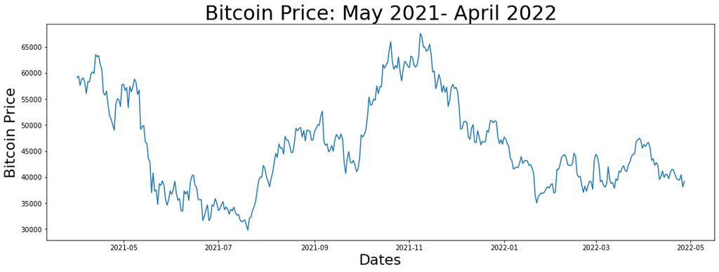

```python
import matplotlib.pyplot as plt
#plt(btc_actual_data['Bitcoin_Price'])
fig,ax = plt.subplots()
fig = plt.gcf()
fig.set_size_inches(18, 6)
ax.plot(btc_actual_data.Date, btc_actual_data.Bitcoin_Price)
plt.xlabel('Dates',fontsize=22)
plt.ylabel('Bitcoin Price',fontsize=22)
plt.title('Bitcoin Price: May 2021- April 2022',fontsize=30)
plt.show()
```

```python
range(btc_actual_data.shape[0])
```

```
range(0, 392)
```

```python
#Creating forward 1 day offset
btc_offset_df=btc_actual_data.loc[:,['Date','Bitcoin_Price']].copy()
btc_offset_df.set_index('Date', inplace=True)
btc_offset_df=btc_offset_df.shift(periods=-1)
btc_offset_df.reset_index(inplace=True)
btc_offset_df.columns=['Date','Bitcoin_target_price']
btc_offset_df.head()
```

|  | Date | Bitcoin_target_price |
| --- | --- | --- |
| 0 | 2021-04-01 | 59384.312500 |
| 1 | 2021-04-02 | 57603.890625 |
| 2 | 2021-04-03 | 58758.554688 |
| 3 | 2021-04-04 | 59057.878906 |
| 4 | 2021-04-05 | 58192.359375 |

```python
# Creating backward offsets
btc_backward_offset_df=btc_actual_data.loc[:,['Date','Bitcoin_Price']].copy()
btc_backward_offset_df.set_index('Date', inplace=True)
btc_backward_offset_df=btc_backward_offset_df.shift(periods=1)
btc_backward_offset_df.reset_index(inplace=True)
btc_backward_offset_df.columns=['Date','Price_D-1']
#-------------------------------------------------------------------------------------------------------------------------------
btc_backward_offset_df2=btc_actual_data.loc[:,['Date','Bitcoin_Price']].copy()
btc_backward_offset_df2.set_index('Date', inplace=True)
btc_backward_offset_df2=btc_backward_offset_df2.shift(periods=2)
btc_backward_offset_df2.reset_index(inplace=True)
btc_backward_offset_df2.columns=['Date','Price_D-2']
```

```python
#pd.concat([df1,df2],axis=1)
print(btc_offset_df.shape)
print(btc_backward_offset_df.shape)
print(btc_backward_offset_df2.shape)
```

```
(392, 2)
(392, 2)
(392, 2)
```

```python
btc_price_df=pd.concat([btc_offset_df,btc_backward_offset_df['Price_D-1'],btc_backward_offset_df2['Price_D-2']],axis=1)
btc_price_df.head()
```

|  | Date | Bitcoin_target_price | Price_D-1 | Price_D-2 |
| --- | --- | --- | --- | --- |
| 0 | 2021-04-01 | 59384.312500 | NaN | NaN |
| 1 | 2021-04-02 | 57603.890625 | 59095.808594 | NaN |
| 2 | 2021-04-03 | 58758.554688 | 59384.312500 | 59095.808594 |
| 3 | 2021-04-04 | 59057.878906 | 57603.890625 | 59384.312500 |
| 4 | 2021-04-05 | 58192.359375 | 58758.554688 | 57603.890625 |

```python
btc_actual_data.columns=['Date','Btc_current_price','Volume']
btc_actual_data=pd.merge(btc_actual_data,
                            btc_price_df,
                            how="left",
                            left_on='Date',
                            right_on='Date')
btc_actual_data.head()
```

|  | Date | Btc_current_price | Volume | Bitcoin_target_price | Price_D-1 | Price_D-2 |
| --- | --- | --- | --- | --- | --- | --- |
| 0 | 2021-04-01 | 59095.808594 | 61669163792 | 59384.312500 | NaN | NaN |
| 1 | 2021-04-02 | 59384.312500 | 58727860620 | 57603.890625 | 59095.808594 | NaN |
| 2 | 2021-04-03 | 57603.890625 | 59641344484 | 58758.554688 | 59384.312500 | 59095.808594 |
| 3 | 2021-04-04 | 58758.554688 | 50749662970 | 59057.878906 | 57603.890625 | 59384.312500 |
| 4 | 2021-04-05 | 59057.878906 | 60706272115 | 58192.359375 | 58758.554688 | 57603.890625 |

Merging the Tweets data with BTC Price data

```python
final_training_data=pd.merge(day_level_btc_raw_data_eng,
                            btc_actual_data,
                            how="left",
                            left_on='Date',
                            right_on='Date')
```

```python
final_training_data.info()
```

```
<class 'pandas.core.frame.DataFrame'>
Int64Index: 351 entries, 0 to 350
Data columns (total 27 columns):
 #   Column                                   Non-Null Count  Dtype
---  ------                                   --------------  -----
 0   Date                                     351 non-null    datetime64[ns]
 1   tweet_volume                             351 non-null    int64
 2   day_of_week                              351 non-null    object
 3   likes_greater_than_0                     351 non-null    int32
 4   likes_greater_than_1                     351 non-null    int32
 5   likes_greater_than_10                    351 non-null    int32
 6   likes_greater_than_100                   351 non-null    int32
 7   likes_greater_than_1000                  351 non-null    int32
 8   distinct_users                           351 non-null    int64
 9   hour_of_day_0_6                          351 non-null    int32
```

[output cut: 19 more lines]

```python
final_training_data.head()
```

|  | Date | tweet_volume | day_of_week | likes_greater_than_0 | likes_greater_than_1 | likes_greater_than_10 | likes_greater_than_100 | likes_greater_than_1000 | distinct_users | hour_of_day_0_6 | ... | negative_verified | neutral_verified | positive_verified | tweets_by_users_with_followers_verified | retweet_perc | Btc_current_price | Volume | Bitcoin_target_price | Price_D-1 | Price_D-2 |
| --- | --- | --- | --- | --- | --- | --- | --- | --- | --- | --- | --- | --- | --- | --- | --- | --- | --- | --- | --- | --- | --- |
| 0 | 2021-05-01 | 38231 | Saturday | 16588 | 9177 | 2248 | 476 | 74 | 21262 | 7514 | ... | 19.601329 | 33.887043 | 46.511628 | 301 | 0.144935 | 57828.050781 | 42836427360 | 56631.078125 | 57750.175781 | 53555.109375 |
| 1 | 2021-05-02 | 36966 | Sunday | 15005 | 8179 | 1921 | 383 | 55 | 20199 | 7520 | ... | 20.000000 | 29.803922 | 50.196078 | 255 | 0.134583 | 56631.078125 | 38177405335 | 57200.292969 | 57828.050781 | 57750.175781 |
| 2 | 2021-05-03 | 42909 | Monday | 17770 | 9975 | 2450 | 516 | 63 | 22072 | 8499 | ... | 11.815068 | 36.643836 | 51.541096 | 584 | 0.142721 | 57200.292969 | 51713139031 | 53333.539063 | 56631.078125 | 57828.050781 |
| 3 | 2021-05-04 | 44743 | Tuesday | 18822 | 10588 | 2532 | 484 | 63 | 22983 | 8158 | ... | 11.397849 | 37.419355 | 51.182796 | 465 | 0.143576 | 53333.539063 | 68564706967 | 57424.007813 | 57200.292969 | 56631.078125 |
| 4 | 2021-05-05 | 48410 | Wednesday | 19656 | 10934 | 2660 | 536 | 85 | 24988 | 9646 | ... | 14.988290 | 33.021077 | 51.990632 | 427 | 0.139207 | 57424.007813 | 69241316747 | 56396.515625 | 53333.539063 | 57200.292969 |

5 rows × 27 columns

```python
#final_training_data.to_csv("final_training_data.csv",index=0)
```

```python
final_training_data.head()
```

|  | Date | tweet_volume | day_of_week | likes_greater_than_0 | likes_greater_than_1 | likes_greater_than_10 | likes_greater_than_100 | likes_greater_than_1000 | distinct_users | hour_of_day_0_6 | ... | negative_verified | neutral_verified | positive_verified | tweets_by_users_with_followers_verified | retweet_perc | Btc_current_price | Volume | Bitcoin_target_price | Price_D-1 | Price_D-2 |
| --- | --- | --- | --- | --- | --- | --- | --- | --- | --- | --- | --- | --- | --- | --- | --- | --- | --- | --- | --- | --- | --- |
| 0 | 2021-05-01 | 38231 | Saturday | 16588 | 9177 | 2248 | 476 | 74 | 21262 | 7514 | ... | 19.601329 | 33.887043 | 46.511628 | 301 | 0.144935 | 57828.050781 | 42836427360 | 56631.078125 | 57750.175781 | 53555.109375 |
| 1 | 2021-05-02 | 36966 | Sunday | 15005 | 8179 | 1921 | 383 | 55 | 20199 | 7520 | ... | 20.000000 | 29.803922 | 50.196078 | 255 | 0.134583 | 56631.078125 | 38177405335 | 57200.292969 | 57828.050781 | 57750.175781 |
| 2 | 2021-05-03 | 42909 | Monday | 17770 | 9975 | 2450 | 516 | 63 | 22072 | 8499 | ... | 11.815068 | 36.643836 | 51.541096 | 584 | 0.142721 | 57200.292969 | 51713139031 | 53333.539063 | 56631.078125 | 57828.050781 |
| 3 | 2021-05-04 | 44743 | Tuesday | 18822 | 10588 | 2532 | 484 | 63 | 22983 | 8158 | ... | 11.397849 | 37.419355 | 51.182796 | 465 | 0.143576 | 53333.539063 | 68564706967 | 57424.007813 | 57200.292969 | 56631.078125 |
| 4 | 2021-05-05 | 48410 | Wednesday | 19656 | 10934 | 2660 | 536 | 85 | 24988 | 9646 | ... | 14.988290 | 33.021077 | 51.990632 | 427 | 0.139207 | 57424.007813 | 69241316747 | 56396.515625 | 53333.539063 | 57200.292969 |

5 rows × 27 columns

# Exploratory Data Analysis

```python
final_training_data.head()
```

|  | Date | tweet_volume | day_of_week | likes_greater_than_0 | likes_greater_than_1 | likes_greater_than_10 | likes_greater_than_100 | likes_greater_than_1000 | distinct_users | hour_of_day_0_6 | ... | negative_verified | neutral_verified | positive_verified | tweets_by_users_with_followers_verified | retweet_perc | Btc_current_price | Volume | Bitcoin_target_price | Price_D-1 | Price_D-2 |
| --- | --- | --- | --- | --- | --- | --- | --- | --- | --- | --- | --- | --- | --- | --- | --- | --- | --- | --- | --- | --- | --- |
| 0 | 2021-05-01 | 38231 | Saturday | 16588 | 9177 | 2248 | 476 | 74 | 21262 | 7514 | ... | 19.601329 | 33.887043 | 46.511628 | 301 | 0.144935 | 57828.050781 | 42836427360 | 56631.078125 | 57750.175781 | 53555.109375 |
| 1 | 2021-05-02 | 36966 | Sunday | 15005 | 8179 | 1921 | 383 | 55 | 20199 | 7520 | ... | 20.000000 | 29.803922 | 50.196078 | 255 | 0.134583 | 56631.078125 | 38177405335 | 57200.292969 | 57828.050781 | 57750.175781 |
| 2 | 2021-05-03 | 42909 | Monday | 17770 | 9975 | 2450 | 516 | 63 | 22072 | 8499 | ... | 11.815068 | 36.643836 | 51.541096 | 584 | 0.142721 | 57200.292969 | 51713139031 | 53333.539063 | 56631.078125 | 57828.050781 |
| 3 | 2021-05-04 | 44743 | Tuesday | 18822 | 10588 | 2532 | 484 | 63 | 22983 | 8158 | ... | 11.397849 | 37.419355 | 51.182796 | 465 | 0.143576 | 53333.539063 | 68564706967 | 57424.007813 | 57200.292969 | 56631.078125 |
| 4 | 2021-05-05 | 48410 | Wednesday | 19656 | 10934 | 2660 | 536 | 85 | 24988 | 9646 | ... | 14.988290 | 33.021077 | 51.990632 | 427 | 0.139207 | 57424.007813 | 69241316747 | 56396.515625 | 53333.539063 | 57200.292969 |

5 rows × 27 columns

```python
final_training_data.shape
```

```
(351, 27)
```

```python
final_training_data.columns
```

```
Index(['Date', 'tweet_volume', 'day_of_week', 'likes_greater_than_0',
       'likes_greater_than_1', 'likes_greater_than_10',
       'likes_greater_than_100', 'likes_greater_than_1000', 'distinct_users',
       'hour_of_day_0_6', 'hour_of_day_6_12', 'hour_of_day_12_18',
       'hour_of_day_18_24', 'negative_1l', 'neutral_1l', 'positive_1l',
       'tweets_by_users_with_followers_1l', 'negative_verified',
       'neutral_verified', 'positive_verified',
       'tweets_by_users_with_followers_verified', 'retweet_perc',
       'Btc_current_price', 'Volume', 'Bitcoin_target_price', 'Price_D-1',
       'Price_D-2'],
      dtype='object')
```

```python
#continues_fields=['tweet_volume', 'likes_greater_than_0','likes_greater_than_1', 'likes_greater_than_10','likes_greater_than_100', 'likes_greater_than_1000', 'distinct_users',
#'hour_of_day_0_6', 'hour_of_day_6_12', 'hour_of_day_12_18','hour_of_day_18_24', 'retweet_perc','positive_tweets_perc','negative_tweets_perc', 'neutral_tweets_perc','Bitcoin_Price', 'Volume']
#removing sentiment fields

continues_fields=['tweet_volume', 'likes_greater_than_0','likes_greater_than_1', 'likes_greater_than_10','likes_greater_than_100', 'likes_greater_than_1000', 'distinct_users',
'hour_of_day_0_6', 'hour_of_day_6_12', 'hour_of_day_12_18','hour_of_day_18_24', 'negative_1l', 'neutral_1l', 'positive_1l','tweets_by_users_with_followers_1l', 'negative_verified','neutral_verified', 'positive_verified',
'tweets_by_users_with_followers_verified','retweet_perc','Btc_current_price', 'Volume','Bitcoin_target_price','Price_D-1','Price_D-2']
correlation_df=final_training_data.loc[:,continues_fields]
correlation_df.corr(method ='pearson')
```

|  | tweet_volume | likes_greater_than_0 | likes_greater_than_1 | likes_greater_than_10 | likes_greater_than_100 | likes_greater_than_1000 | distinct_users | hour_of_day_0_6 | hour_of_day_6_12 | hour_of_day_12_18 | ... | negative_verified | neutral_verified | positive_verified | tweets_by_users_with_followers_verified | retweet_perc | Btc_current_price | Volume | Bitcoin_target_price | Price_D-1 | Price_D-2 |
| --- | --- | --- | --- | --- | --- | --- | --- | --- | --- | --- | --- | --- | --- | --- | --- | --- | --- | --- | --- | --- | --- |
| tweet_volume | 1.000000 | 0.985473 | 0.973519 | 0.961778 | 0.933125 | 0.855953 | 0.985694 | 0.863461 | 0.930848 | 0.932750 | ... | 0.038513 | -0.025046 | -0.004558 | 0.855313 | 0.119885 | -0.016136 | 0.655194 | -0.023065 | 0.011097 | 0.038895 |
| likes_greater_than_0 | 0.985473 | 1.000000 | 0.996244 | 0.980347 | 0.956007 | 0.896450 | 0.967644 | 0.840516 | 0.899357 | 0.919154 | ... | 0.023049 | 0.010000 | -0.025712 | 0.844899 | 0.125844 | 0.018689 | 0.619570 | 0.012456 | 0.040790 | 0.066601 |
| likes_greater_than_1 | 0.973519 | 0.996244 | 1.000000 | 0.987501 | 0.965142 | 0.911354 | 0.950306 | 0.822842 | 0.880958 | 0.909098 | ... | -0.001658 | 0.025061 | -0.021862 | 0.846627 | 0.140255 | 0.058521 | 0.597335 | 0.051962 | 0.077112 | 0.101058 |
| likes_greater_than_10 | 0.961778 | 0.980347 | 0.987501 | 1.000000 | 0.986745 | 0.922428 | 0.937223 | 0.794358 | 0.862083 | 0.901867 | ... | -0.032012 | 0.005408 | 0.017962 | 0.885820 | 0.204959 | 0.093084 | 0.590151 | 0.084462 | 0.105742 | 0.125115 |
| likes_greater_than_100 | 0.933125 | 0.956007 | 0.965142 | 0.986745 | 1.000000 | 0.942676 | 0.907208 | 0.753159 | 0.826179 | 0.873410 | ... | -0.042228 | 0.018914 | 0.012860 | 0.877014 | 0.217329 | 0.083020 | 0.546293 | 0.075667 | 0.085014 | 0.099500 |
| likes_greater_than_1000 | 0.855953 | 0.896450 | 0.911354 | 0.922428 | 0.942676 | 1.000000 | 0.814496 | 0.679276 | 0.731977 | 0.788108 | ... | -0.042029 | 0.059630 | -0.024732 | 0.767204 | 0.099581 | 0.038331 | 0.387388 | 0.028609 | 0.031313 | 0.039743 |
| distinct_users | 0.985694 | 0.967644 | 0.950306 | 0.937223 | 0.907208 | 0.814496 | 1.000000 | 0.865188 | 0.921226 | 0.922695 | ... | 0.047160 | -0.039414 | 0.002461 | 0.827761 | 0.128730 | 0.024344 | 0.697121 | 0.015999 | 0.054135 | 0.083179 |
| hour_of_day_0_6 | 0.863461 | 0.840516 | 0.822842 | 0.794358 | 0.753159 | 0.679276 | 0.865188 | 1.000000 | 0.883870 | 0.706714 | ... | 0.059154 | -0.013926 | -0.029575 | 0.707208 | 0.014460 | 0.005908 | 0.547745 | -0.002310 | 0.021083 | 0.055414 |
| hour_of_day_6_12 | 0.930848 | 0.899357 | 0.880958 | 0.862083 | 0.826179 | 0.731977 | 0.921226 | 0.883870 | 1.000000 | 0.839761 | ... | 0.050726 | -0.027785 | -0.010789 | 0.782851 | 0.141221 | -0.063697 | 0.628923 | -0.068788 | -0.036988 | -0.006186 |
| hour_of_day_12_18 | 0.932750 | 0.919154 | 0.909098 | 0.901867 | 0.873410 | 0.788108 | 0.922695 | 0.706714 | 0.839761 | 1.000000 | ... | 0.002032 | -0.016072 | 0.013326 | 0.822248 | 0.170676 | -0.018436 | 0.618422 | -0.021855 | 0.010262 | 0.024327 |
| hour_of_day_18_24 | 0.846162 | 0.855084 | 0.854372 | 0.858906 | 0.856044 | 0.830793 | 0.816490 | 0.615852 | 0.666704 | 0.708469 | ... | 0.047937 | -0.033313 | -0.003707 | 0.723901 | 0.065602 | 0.012846 | 0.543544 | 0.003511 | 0.036575 | 0.064748 |
| negative_1l | 0.086669 | 0.069756 | 0.046305 | 0.014438 | -0.011659 | -0.020911 | 0.090823 | 0.074073 | 0.091342 | 0.056456 | ... | 0.741455 | -0.234529 | -0.315540 | -0.069120 | -0.252414 | -0.309306 | 0.071382 | -0.311663 | -0.270592 | -0.228472 |
| neutral_1l | -0.167862 | -0.170269 | -0.167903 | -0.149797 | -0.119974 | -0.161180 | -0.143041 | -0.169250 | -0.133765 | -0.126217 | ... | -0.276793 | 0.459627 | -0.224426 | -0.086859 | 0.273531 | 0.053571 | 0.013496 | 0.070780 | 0.048815 | 0.040984 |
| positive_1l | 0.122549 | 0.137694 | 0.152358 | 0.155745 | 0.141862 | 0.194455 | 0.091914 | 0.133378 | 0.081228 | 0.098570 | ... | -0.239289 | -0.337603 | 0.481965 | 0.147450 | -0.117704 | 0.168575 | -0.067628 | 0.151198 | 0.145311 | 0.122950 |
| tweets_by_users_with_followers_1l | 0.770326 | 0.757721 | 0.759975 | 0.816927 | 0.822621 | 0.693177 | 0.757527 | 0.614025 | 0.705559 | 0.750116 | ... | -0.116267 | -0.122892 | 0.196336 | 0.936801 | 0.516556 | 0.144037 | 0.596160 | 0.142964 | 0.149569 | 0.152560 |
| negative_verified | 0.038513 | 0.023049 | -0.001658 | -0.032012 | -0.042228 | -0.042029 | 0.047160 | 0.059154 | 0.050726 | 0.002032 | ... | 1.000000 | -0.272631 | -0.465743 | -0.092412 | -0.247623 | -0.380866 | 0.011623 | -0.376641 | -0.355319 | -0.319409 |
| neutral_verified | -0.025046 | 0.010000 | 0.025061 | 0.005408 | 0.018914 | 0.059630 | -0.039414 | -0.013926 | -0.027785 | -0.016072 | ... | -0.272631 | 1.000000 | -0.724422 | -0.097370 | -0.084683 | -0.060729 | -0.126461 | -0.056099 | -0.061231 | -0.062327 |
| positive_verified | -0.004558 | -0.025712 | -0.021862 | 0.017962 | 0.012860 | -0.024732 | 0.002461 | -0.029575 | -0.010789 | 0.013326 | ... | -0.465743 | -0.724422 | 1.000000 | 0.155771 | 0.255310 | 0.328746 | 0.107986 | 0.321460 | 0.310903 | 0.286182 |
| tweets_by_users_with_followers_verified | 0.855313 | 0.844899 | 0.846627 | 0.885820 | 0.877014 | 0.767204 | 0.827761 | 0.707208 | 0.782851 | 0.822248 | ... | -0.092412 | -0.097370 | 0.155771 | 1.000000 | 0.373652 | 0.086211 | 0.573700 | 0.080116 | 0.091717 | 0.098705 |
| retweet_perc | 0.119885 | 0.125844 | 0.140255 | 0.204959 | 0.217329 | 0.099581 | 0.128730 | 0.014460 | 0.141221 | 0.170676 | ... | -0.247623 | -0.084683 | 0.255310 | 0.373652 | 1.000000 | 0.209666 | 0.273251 | 0.214680 | 0.180994 | 0.159256 |
| Btc_current_price | -0.016136 | 0.018689 | 0.058521 | 0.093084 | 0.083020 | 0.038331 | 0.024344 | 0.005908 | -0.063697 | -0.018436 | ... | -0.380866 | -0.060729 | 0.328746 | 0.086211 | 0.209666 | 1.000000 | 0.173569 | 0.980279 | 0.980432 | 0.962656 |
| Volume | 0.655194 | 0.619570 | 0.597335 | 0.590151 | 0.546293 | 0.387388 | 0.697121 | 0.547745 | 0.628923 | 0.618422 | ... | 0.011623 | -0.126461 | 0.107986 | 0.573700 | 0.273251 | 0.173569 | 1.000000 | 0.175160 | 0.207639 | 0.235399 |
| Bitcoin_target_price | -0.023065 | 0.012456 | 0.051962 | 0.084462 | 0.075667 | 0.028609 | 0.015999 | -0.002310 | -0.068788 | -0.021855 | ... | -0.376641 | -0.056099 | 0.321460 | 0.080116 | 0.214680 | 0.980279 | 0.175160 | 1.000000 | 0.962730 | 0.945968 |
| Price_D-1 | 0.011097 | 0.040790 | 0.077112 | 0.105742 | 0.085014 | 0.031313 | 0.054135 | 0.021083 | -0.036988 | 0.010262 | ... | -0.355319 | -0.061231 | 0.310903 | 0.091717 | 0.180994 | 0.980432 | 0.207639 | 0.962730 | 1.000000 | 0.980114 |
| Price_D-2 | 0.038895 | 0.066601 | 0.101058 | 0.125115 | 0.099500 | 0.039743 | 0.083179 | 0.055414 | -0.006186 | 0.024327 | ... | -0.319409 | -0.062327 | 0.286182 | 0.098705 | 0.159256 | 0.962656 | 0.235399 | 0.945968 | 0.980114 | 1.000000 |

25 rows × 25 columns

```python
corr = correlation_df.corr()
corr.style.background_gradient(cmap='coolwarm').set_precision(2)
```

|  | tweet_volume | likes_greater_than_0 | likes_greater_than_1 | likes_greater_than_10 | likes_greater_than_100 | likes_greater_than_1000 | distinct_users | hour_of_day_0_6 | hour_of_day_6_12 | hour_of_day_12_18 | hour_of_day_18_24 | negative_1l | neutral_1l | positive_1l | tweets_by_users_with_followers_1l | negative_verified | neutral_verified | positive_verified | tweets_by_users_with_followers_verified | retweet_perc | Btc_current_price | Volume | Bitcoin_target_price | Price_D-1 | Price_D-2 |
| --- | --- | --- | --- | --- | --- | --- | --- | --- | --- | --- | --- | --- | --- | --- | --- | --- | --- | --- | --- | --- | --- | --- | --- | --- | --- |
| tweet_volume | 1.00 | 0.99 | 0.97 | 0.96 | 0.93 | 0.86 | 0.99 | 0.86 | 0.93 | 0.93 | 0.85 | 0.09 | -0.17 | 0.12 | 0.77 | 0.04 | -0.03 | -0.00 | 0.86 | 0.12 | -0.02 | 0.66 | -0.02 | 0.01 | 0.04 |
| likes_greater_than_0 | 0.99 | 1.00 | 1.00 | 0.98 | 0.96 | 0.90 | 0.97 | 0.84 | 0.90 | 0.92 | 0.86 | 0.07 | -0.17 | 0.14 | 0.76 | 0.02 | 0.01 | -0.03 | 0.84 | 0.13 | 0.02 | 0.62 | 0.01 | 0.04 | 0.07 |
| likes_greater_than_1 | 0.97 | 1.00 | 1.00 | 0.99 | 0.97 | 0.91 | 0.95 | 0.82 | 0.88 | 0.91 | 0.85 | 0.05 | -0.17 | 0.15 | 0.76 | -0.00 | 0.03 | -0.02 | 0.85 | 0.14 | 0.06 | 0.60 | 0.05 | 0.08 | 0.10 |
| likes_greater_than_10 | 0.96 | 0.98 | 0.99 | 1.00 | 0.99 | 0.92 | 0.94 | 0.79 | 0.86 | 0.90 | 0.86 | 0.01 | -0.15 | 0.16 | 0.82 | -0.03 | 0.01 | 0.02 | 0.89 | 0.20 | 0.09 | 0.59 | 0.08 | 0.11 | 0.13 |
| likes_greater_than_100 | 0.93 | 0.96 | 0.97 | 0.99 | 1.00 | 0.94 | 0.91 | 0.75 | 0.83 | 0.87 | 0.86 | -0.01 | -0.12 | 0.14 | 0.82 | -0.04 | 0.02 | 0.01 | 0.88 | 0.22 | 0.08 | 0.55 | 0.08 | 0.09 | 0.10 |
| likes_greater_than_1000 | 0.86 | 0.90 | 0.91 | 0.92 | 0.94 | 1.00 | 0.81 | 0.68 | 0.73 | 0.79 | 0.83 | -0.02 | -0.16 | 0.19 | 0.69 | -0.04 | 0.06 | -0.02 | 0.77 | 0.10 | 0.04 | 0.39 | 0.03 | 0.03 | 0.04 |
| distinct_users | 0.99 | 0.97 | 0.95 | 0.94 | 0.91 | 0.81 | 1.00 | 0.87 | 0.92 | 0.92 | 0.82 | 0.09 | -0.14 | 0.09 | 0.76 | 0.05 | -0.04 | 0.00 | 0.83 | 0.13 | 0.02 | 0.70 | 0.02 | 0.05 | 0.08 |
| hour_of_day_0_6 | 0.86 | 0.84 | 0.82 | 0.79 | 0.75 | 0.68 | 0.87 | 1.00 | 0.88 | 0.71 | 0.62 | 0.07 | -0.17 | 0.13 | 0.61 | 0.06 | -0.01 | -0.03 | 0.71 | 0.01 | 0.01 | 0.55 | -0.00 | 0.02 | 0.06 |
| hour_of_day_6_12 | 0.93 | 0.90 | 0.88 | 0.86 | 0.83 | 0.73 | 0.92 | 0.88 | 1.00 | 0.84 | 0.67 | 0.09 | -0.13 | 0.08 | 0.71 | 0.05 | -0.03 | -0.01 | 0.78 | 0.14 | -0.06 | 0.63 | -0.07 | -0.04 | -0.01 |
| hour_of_day_12_18 | 0.93 | 0.92 | 0.91 | 0.90 | 0.87 | 0.79 | 0.92 | 0.71 | 0.84 | 1.00 | 0.71 | 0.06 | -0.13 | 0.10 | 0.75 | 0.00 | -0.02 | 0.01 | 0.82 | 0.17 | -0.02 | 0.62 | -0.02 | 0.01 | 0.02 |
| hour_of_day_18_24 | 0.85 | 0.86 | 0.85 | 0.86 | 0.86 | 0.83 | 0.82 | 0.62 | 0.67 | 0.71 | 1.00 | 0.10 | -0.18 | 0.13 | 0.66 | 0.05 | -0.03 | -0.00 | 0.72 | 0.07 | 0.01 | 0.54 | 0.00 | 0.04 | 0.06 |
| negative_1l | 0.09 | 0.07 | 0.05 | 0.01 | -0.01 | -0.02 | 0.09 | 0.07 | 0.09 | 0.06 | 0.10 | 1.00 | -0.47 | -0.21 | -0.09 | 0.74 | -0.23 | -0.32 | -0.07 | -0.25 | -0.31 | 0.07 | -0.31 | -0.27 | -0.23 |
| neutral_1l | -0.17 | -0.17 | -0.17 | -0.15 | -0.12 | -0.16 | -0.14 | -0.17 | -0.13 | -0.13 | -0.18 | -0.47 | 1.00 | -0.76 | 0.06 | -0.28 | 0.46 | -0.22 | -0.09 | 0.27 | 0.05 | 0.01 | 0.07 | 0.05 | 0.04 |
| positive_1l | 0.12 | 0.14 | 0.15 | 0.16 | 0.14 | 0.19 | 0.09 | 0.13 | 0.08 | 0.10 | 0.13 | -0.21 | -0.76 | 1.00 | -0.00 | -0.24 | -0.34 | 0.48 | 0.15 | -0.12 | 0.17 | -0.07 | 0.15 | 0.15 | 0.12 |
| tweets_by_users_with_followers_1l | 0.77 | 0.76 | 0.76 | 0.82 | 0.82 | 0.69 | 0.76 | 0.61 | 0.71 | 0.75 | 0.66 | -0.09 | 0.06 | -0.00 | 1.00 | -0.12 | -0.12 | 0.20 | 0.94 | 0.52 | 0.14 | 0.60 | 0.14 | 0.15 | 0.15 |
| negative_verified | 0.04 | 0.02 | -0.00 | -0.03 | -0.04 | -0.04 | 0.05 | 0.06 | 0.05 | 0.00 | 0.05 | 0.74 | -0.28 | -0.24 | -0.12 | 1.00 | -0.27 | -0.47 | -0.09 | -0.25 | -0.38 | 0.01 | -0.38 | -0.36 | -0.32 |
| neutral_verified | -0.03 | 0.01 | 0.03 | 0.01 | 0.02 | 0.06 | -0.04 | -0.01 | -0.03 | -0.02 | -0.03 | -0.23 | 0.46 | -0.34 | -0.12 | -0.27 | 1.00 | -0.72 | -0.10 | -0.08 | -0.06 | -0.13 | -0.06 | -0.06 | -0.06 |
| positive_verified | -0.00 | -0.03 | -0.02 | 0.02 | 0.01 | -0.02 | 0.00 | -0.03 | -0.01 | 0.01 | -0.00 | -0.32 | -0.22 | 0.48 | 0.20 | -0.47 | -0.72 | 1.00 | 0.16 | 0.26 | 0.33 | 0.11 | 0.32 | 0.31 | 0.29 |
| tweets_by_users_with_followers_verified | 0.86 | 0.84 | 0.85 | 0.89 | 0.88 | 0.77 | 0.83 | 0.71 | 0.78 | 0.82 | 0.72 | -0.07 | -0.09 | 0.15 | 0.94 | -0.09 | -0.10 | 0.16 | 1.00 | 0.37 | 0.09 | 0.57 | 0.08 | 0.09 | 0.10 |
| retweet_perc | 0.12 | 0.13 | 0.14 | 0.20 | 0.22 | 0.10 | 0.13 | 0.01 | 0.14 | 0.17 | 0.07 | -0.25 | 0.27 | -0.12 | 0.52 | -0.25 | -0.08 | 0.26 | 0.37 | 1.00 | 0.21 | 0.27 | 0.21 | 0.18 | 0.16 |
| Btc_current_price | -0.02 | 0.02 | 0.06 | 0.09 | 0.08 | 0.04 | 0.02 | 0.01 | -0.06 | -0.02 | 0.01 | -0.31 | 0.05 | 0.17 | 0.14 | -0.38 | -0.06 | 0.33 | 0.09 | 0.21 | 1.00 | 0.17 | 0.98 | 0.98 | 0.96 |
| Volume | 0.66 | 0.62 | 0.60 | 0.59 | 0.55 | 0.39 | 0.70 | 0.55 | 0.63 | 0.62 | 0.54 | 0.07 | 0.01 | -0.07 | 0.60 | 0.01 | -0.13 | 0.11 | 0.57 | 0.27 | 0.17 | 1.00 | 0.18 | 0.21 | 0.24 |
| Bitcoin_target_price | -0.02 | 0.01 | 0.05 | 0.08 | 0.08 | 0.03 | 0.02 | -0.00 | -0.07 | -0.02 | 0.00 | -0.31 | 0.07 | 0.15 | 0.14 | -0.38 | -0.06 | 0.32 | 0.08 | 0.21 | 0.98 | 0.18 | 1.00 | 0.96 | 0.95 |
| Price_D-1 | 0.01 | 0.04 | 0.08 | 0.11 | 0.09 | 0.03 | 0.05 | 0.02 | -0.04 | 0.01 | 0.04 | -0.27 | 0.05 | 0.15 | 0.15 | -0.36 | -0.06 | 0.31 | 0.09 | 0.18 | 0.98 | 0.21 | 0.96 | 1.00 | 0.98 |
| Price_D-2 | 0.04 | 0.07 | 0.10 | 0.13 | 0.10 | 0.04 | 0.08 | 0.06 | -0.01 | 0.02 | 0.06 | -0.23 | 0.04 | 0.12 | 0.15 | -0.32 | -0.06 | 0.29 | 0.10 | 0.16 | 0.96 | 0.24 | 0.95 | 0.98 | 1.00 |

```python
correlation_df.corrwith(correlation_df["Bitcoin_target_price"])
```

```
tweet_volume                              -0.023065
likes_greater_than_0                       0.012456
likes_greater_than_1                       0.051962
likes_greater_than_10                      0.084462
likes_greater_than_100                     0.075667
likes_greater_than_1000                    0.028609
distinct_users                             0.015999
hour_of_day_0_6                           -0.002310
hour_of_day_6_12                          -0.068788
hour_of_day_12_18                         -0.021855
hour_of_day_18_24                          0.003511
negative_1l                               -0.311663
neutral_1l                                 0.070780
positive_1l                                0.151198
tweets_by_users_with_followers_1l          0.142964
negative_verified                         -0.376641
neutral_verified                          -0.056099
positive_verified                          0.321460
tweets_by_users_with_followers_verified    0.080116
retweet_perc                               0.214680
Btc_current_price                          0.980279
Volume                                     0.175160
Bitcoin_target_price                       1.000000
dtype: float64
```

Exploring 'Bitcoin_Price'